# Text Mining: Extracción de información de documentos Ebooks

by [María Luisa Duque](https://www.linkedin.com/in/marialuisaduque/)

2020-06-17

## Libros del Proyecto Gutemberg: *Veinte poemas para ser leídos en el tranvía* por Oliverio Girondo

Dado el gusto de la autora de la presente tarea por la poesía, vamos a escoger aquí analizar el libro [Veinte poemas para ser leídos en el tranvía](https://www.gutenberg.org/ebooks/58103) con el [gutenbergr package](https://github.com/ropenscilabs/gutenbergr) del [Proyecto Gutemberg](https://www.gutenberg.org/).

Primero, cargamos las librerías necesarias:

```r
library(dplyr)
library(tidyr)
library(WikipediR)
library(WikipediaR)
library(jsonlite)
library(tm)
library(wordcloud)
library(ggplot2)
library(knitr)
```

```r
if(!is.element("tidyverse", installed.packages()[, 1]))
      install.packages("tidyverse", repos = 'http://cran.us.r-project.org')
library(tidyverse)
if(!is.element("(gutenbergr", installed.packages()[, 1]))
      devtools::install_github("ropenscilabs/gutenbergr")
library(gutenbergr)
if(!is.element("tidytext", installed.packages()[, 1]))
      install.packages("tidytext", repos = 'http://cran.us.r-project.org')
library(tidytext)
if(!is.element("drlib", installed.packages()[, 1]))
      devtools::install_github("dgrtwo/drlib")
library(drlib)
if(!is.element("quanteda", installed.packages()[, 1]))
      install.packages("quanteda", repos = 'http://cran.us.r-project.org')
library(quanteda)
if(!is.element("stm", installed.packages()[, 1]))
      install.packages("stm", repos = 'http://cran.us.r-project.org')
library(stm)
```

Sacamos los datos del Proyecto Gutemberg

```r
# # Veinte poemas para ser leídos en el tranvía de Oliverio Girondo
girondo_raw <- gutenberg_download(58103)
```

```
## Determining mirror for Project Gutenberg from http://www.gutenberg.org/robot/harvest
```

```
## Using mirror http://aleph.gutenberg.org
```

```r
# La siguiente parte del texto se incluye para libros que incluyan varias partes
# En nuestro caso, '20 poemas para ser leídos en el tranvía', aporta muy poco
girondo <- girondo_raw %>%
    # Creamos una columna nueva, story, que inicialmente es igual a text
    mutate(story = text) %>%

    fill(story) %>%
    filter(story != "20 POEMAS PARA SER LEÍDOS EN EL TRAVÍA") %>%
    mutate(story = factor(story, levels = unique(story)))

girondo
```

```
## # A tibble: 797 x 3
##    gutenberg_id text                             story
##           <int> <chr>                            <fct>
##  1        58103 "                           OLI~ "                           OL~
##  2        58103 ""                               ""
##  3        58103 "                              ~ "                             ~
##  4        58103 ""                               ""
##  5        58103 "                            PA~ "                            P~
##  6        58103 "                             E~ "                             ~
##  7        58103 ""                               ""
##  8        58103 ""                               ""
##  9        58103 "                       _Ilustr~ "                       _Ilust~
## 10        58103 ""                               ""
## # ... with 787 more rows
```

```r
kable(head(girondo))
```

[output not shown]

```r
kable(summary(girondo))
```

|  | gutenberg_id | text | story |
| --- | --- | --- | --- |
|  | Min. :58103 | Length:797 | :381 |
|  | 1st Qu.:58103 | Class :character | [Imagen] : 9 |
|  | Median :58103 | Mode :character | “HUMILITAS” : 5 |
|  | Mean :58103 | NA | VENECIA, JULIO 1921. : 2 |
|  | 3rd Qu.:58103 | NA | pintan las inglesas. : 2 |
|  | Max. :58103 | NA | Isola Bella, con su palacio y hasta con el lema del escudo de sus: 2 |
|  | NA | NA | (Other) :396 |

Structure o str.

```r
kable(str(girondo))
```

```
## tibble [797 x 3] (S3: tbl_df/tbl/data.frame)
##  $ gutenberg_id: int [1:797] 58103 58103 58103 58103 58103 58103 58103 58103 58103 58103 ...
##  $ text        : chr [1:797] "                           OLIVERIO GIRONDO" "" "                               20 POEMAS" "" ...
##  $ story       : Factor w/ 401 levels "                           OLIVERIO GIRONDO",..: 1 2 3 2 4 5 2 2 6 2 ...
```

[output not shown]

Obtenemos las stopwords del paquete **stopwords** en castellano/español.

```r
# Creamos el dataframe stopwords_es
stopwords_es <- as.data.frame(stopwords::stopwords("es"))

# Cambiamos de nombre a la variables
names(stopwords_es) <- "word"

# Vemos las stopwords
stopwords_es
```

```
##             word
## 1             de
## 2             la
## 3            que
## 4             el
## 5             en
## 6              y
## 7              a
## 8            los
## 9            del
## 10            se
## 11           las
## 12           por
## 13            un
## 14          para
```

[output cut: 294 more lines]

308 stopwords.

Vamos a incluir algunos terminos más.

```r
# Creamos un data.frame con otras palabras
otras_palabras <- data.frame(word = c("cuantos", "posibles", "si", "tan", "aquí",
                                      "pues", "ay", "tras", "mientras", "las")) # Podemos incluir los que veamos necesarios

# Y con rbind, lo unimos al que teníamos
stopwords_es <- rbind(stopwords_es, otras_palabras)
```

Pasamos a formato tbl, es el formato que utiliza dplyr.

```r
stopwords_es_tbl<- as.tbl(stopwords_es)
```

Vamos a transformar el texto con la función unnest_tokens(). Además, vamos a utilizar la función stopwords.

```r
tidy_girondo <- girondo %>%
    # Incluimos una columna, line, con el número de línea
    mutate(line = row_number()) %>%

    # Aplicamos unnest_tokens()
    unnest_tokens(word, text) %>%
    # anti_join(stop_words)
    # anti_join(stopwords(language = "es"))

    # Quitamos las stopwords
    anti_join(stopwords_es_tbl, by ="word")
```

```r
tidy_girondo %>%
    # Contamos word
    count(word, sort = TRUE)
```

```
## # A tibble: 1,221 x 2
##    word        n
##    <chr>   <int>
##  1 imagen     10
##  2 mujeres    10
##  3 ojos       10
##  4 1920        9
##  5 ciudad      9
##  6 mar         9
##  7 vereda      9
##  8 olor        8
##  9 pasar       8
## 10 1921        7
## # ... with 1,211 more rows
```

“Imagen”, “mujeres” y “ojos” son los terminos que aparecen mayor número de veces. Comprobemos este hecho generando una nube de palabras.

### Wordcloud

Para poder generar un *wordcloud*, en este caso con mínima frecuencia de aparición igual a 5, debemos generar primero el corpus y aplicar *tm*, un poco de limpieza.

```r
corpus <- Corpus(VectorSource(girondo_raw), readerControl = list(language = "es"))
corpus
```

```
## <<SimpleCorpus>>
## Metadata:  corpus specific: 1, document level (indexed): 0
## Content:  documents: 2
```

Quitamos los espacios en blanco:

```r
corpus <- tm_map(corpus, stripWhitespace)
```

Quitamos las stopwords en español:

```r
corpus <- tm_map(corpus, removeWords, stopwords('es'))
```

Quitamos el resto de signos de puntuación que queden, con la opción **removePuntuation**:

```r
corpus <- tm_map(corpus, removePunctuation)
```

Eliminamos los números:

```r
corpus <- tm_map(corpus, removeNumbers)
```

```r
corpus <- tm_map(corpus, removeWords, "las")
```

```r
corpus <- tm_map(corpus, removeWords, "mientras")
```

**WordCloud**.

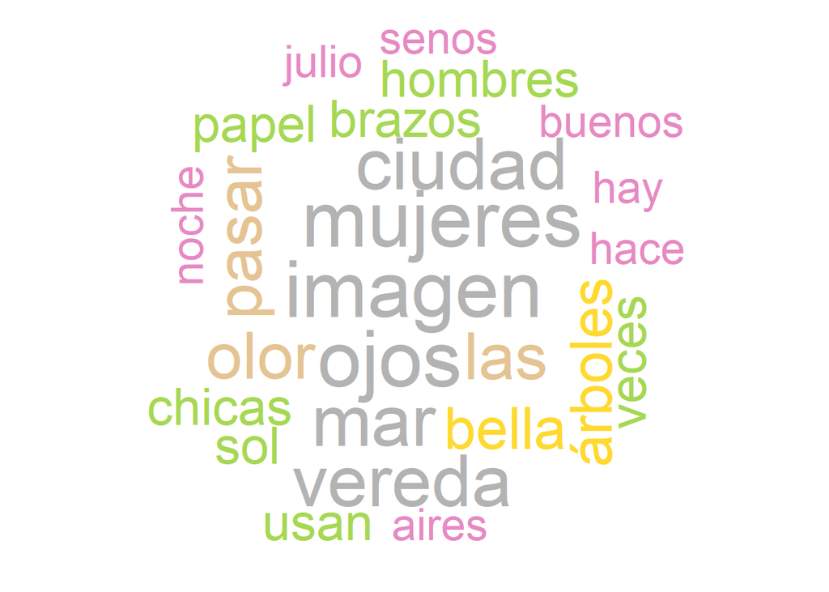

```r
wordcloud(corpus, min.freq = 5, random.order = FALSE, colors = brewer.pal(8, "Set2"))
```

### Topic model

Pasamos al topic model. Vamos a identificar los temas principales dentro del texto a ser posible de forma automática (aprendizaje no supervisado).

Vamos a empezar creando el dfm para poder usar la función stm después.

```r
girondo_dfm <- tidy_girondo %>%
    # Contamos por story y por word y ordenamos
    count(story, word, sort = TRUE) %>%

    # Y convertimos en un objeto dfm con la función cast_dfm
    cast_dfm(story, word, n)
```

```r
class(girondo_dfm)
```

```
## [1] "dfm"
## attr(,"package")
## [1] "quanteda"
```

```r
girondo_sparse <- tidy_girondo %>%
    # Contamos por story y por word y ordenamos
    count(story, word, sort = TRUE) %>%


    cast_sparse(story, word, n)
```

Tenemos una matriz tipo sparse en la que hemos separado la lista de terminos y las palabras donde aparecen. Realizamos esta conversión a matriz tipo sparse porque es el formato solicitado por la función stm.

```r
class(girondo_sparse)
```

```
## [1] "dgCMatrix"
## attr(,"package")
## [1] "Matrix"
```

Para hacer el topic modeling, la función **stm** es la que realiza todo el trabajo, le decimos cuantos bloques K queremos (o k grupos, es basicamente como un k-means aplicado a este tratamiento de textos), en nuestro caso 6.

```r
topic_model <- stm(girondo_dfm, K = 6, verbose = FALSE, init.type = "Spectral")
```

Vemos el summary del resultado.

```r
summary(topic_model)
```

```
## A topic model with 6 topics, 400 documents and a 1221 word dictionary.
```

```
## Topic 1 Top Words:
##       Highest Prob: imagen, vereda, mujeres, olor, pasar, árboles, bella
##       FREX: imagen, vereda, mujeres, olor, pasar, árboles, bella
##       Lift: _ilustraciones, autor_, enjugan, lágrimas, mantos, rígidos, rubí
##       Score: _ilustraciones, autor_, vereda, imagen, bajo, miedo, sexo
## Topic 2 Top Words:
##       Highest Prob: imagen, vereda, mujeres, olor, pasar, árboles, bella
##       FREX: imagen, vereda, mujeres, olor, pasar, árboles, bella
##       Lift: 20, poemas, enjugan, lágrimas, mantos, rígidos, rubí
##       Score: 20, poemas, vereda, imagen, bajo, miedo, sexo
## Topic 3 Top Words:
##       Highest Prob: imagen, vereda, mujeres, olor, pasar, árboles, bella
##       FREX: imagen, vereda, mujeres, olor, pasar, árboles, bella
##       Lift: acariciar, duerme, enjugan, lágrimas, mantos, rígidos, rubí
##       Score: acariciar, duerme, vereda, imagen, bajo, miedo, sexo
## Topic 4 Top Words:
##       Highest Prob: imagen, vereda, mujeres, olor, pasar, árboles, bella
##       FREX: imagen, vereda, mujeres, olor, pasar, árboles, bella
##       Lift: adioses, naufragio, enjugan, lágrimas, mantos, rígidos, rubí
##       Score: adioses, naufragio, vereda, imagen, bajo, miedo, sexo
## Topic 5 Top Words:
##       Highest Prob: 1920, 1921, mar, ojos, julio, aires, buenos
##       FREX: 1921, 1920, julio, aires, buenos, piernas, humilitas
##       Lift: amputadas, dulzor, escenario, humear, romanzas, adelgazan, capotas
##       Score: 1920, amputadas, 1921, piernas, julio, aires, buenos
## Topic 6 Top Words:
##       Highest Prob: mujeres, ojos, imagen, pasar, ciudad, bella, isola
##       FREX: mujeres, ojos, imagen, pasar, ciudad, bella, isola
##       Lift: apaguen, luciérnagas, alimentan, pétalos, rosa, escalas, guitarras
##       Score: apaguen, luciérnagas, bella, isola, mujeres, hace, faroles
```

Nos ha divido en 6 grupos, los 6 grupos más parecidos, habría que entender el sentido de porqué ha escogido los terminos en cada unos de estos grupos, el sentido común.

Vamos a verlo de forma gráfica.

```r
# Creamos un td_beta como tidy tibble de topic_model
td_beta <- tidy(topic_model)
# Vemos la clase
class(td_beta)
```

```
## [1] "tbl_df"     "tbl"        "data.frame"
```

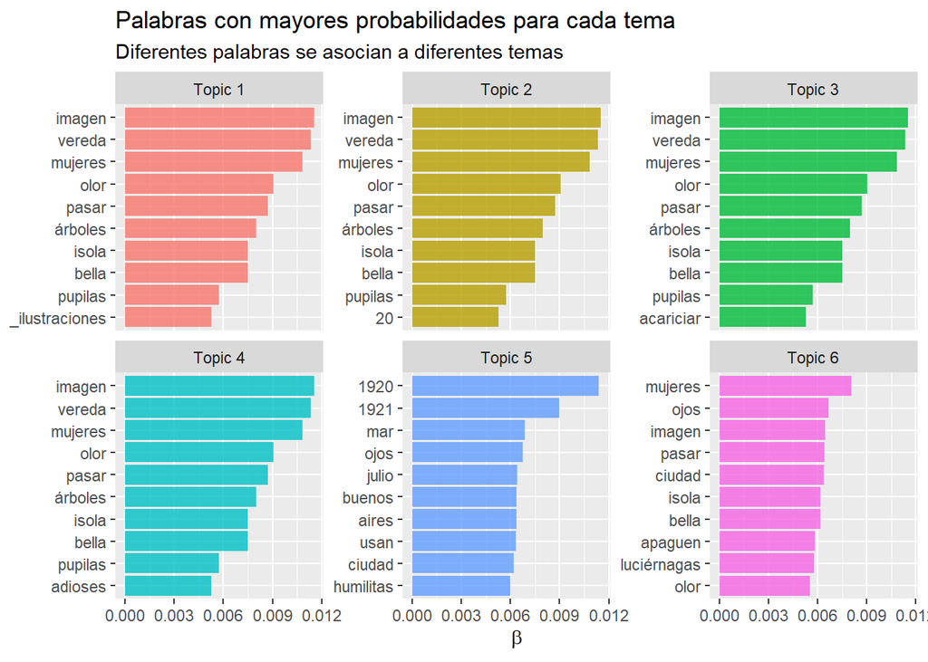

```r
td_beta %>%

    # Agrupamos por topic
    group_by(topic) %>%

    # Nos quedamos con los top n (10) sobre el valor de beta
    top_n(10, beta) %>%

    # Desagrupamos
    ungroup() %>%

    # Cambiamos y reordenamos. Tres columnas: topic, term, beta
    mutate(topic = paste0("Topic ", topic),
           term = reorder_within(term, beta, topic)) %>%

    # Creamos un gráfico
    ggplot(aes(term, beta, fill = as.factor(topic))) +
    geom_col(alpha = 0.8, show.legend = FALSE) +
    facet_wrap(~ topic, scales = "free_y") +
    coord_flip() +
    scale_x_reordered() +
    labs(x        = NULL,
         y        = expression(beta),
         title    = "Palabras con mayores probabilidades para cada tema",
         subtitle = "Diferentes palabras se asocian a diferentes temas")
```

De forma gráfica, parece observarse, los grupos 1, 2, 3 y 4 son muy parecidos. Los Topic5 y Topic6 parecen más diferentes.

Lo hacemos para cuatro grupos, k=4.

```r
topic_model <- stm(girondo_dfm, K = 4, verbose = FALSE, init.type = "Spectral")
# Creamos un td_beta como tidy tibble de topic_model
td_beta <- tidy(topic_model)

# Vemos la clase
class(td_beta)
```

```
## [1] "tbl_df"     "tbl"        "data.frame"
```

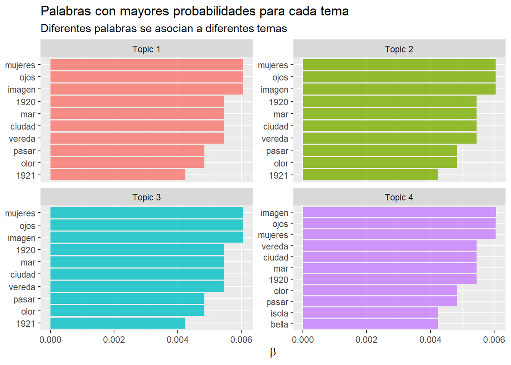

```r
td_beta %>%

    # Agrupamos por topic
    group_by(topic) %>%

    # Nos quedamos con los top n (10) sobre el valor de beta
    top_n(10, beta) %>%

    # Desagrupamos
    ungroup() %>%

    # Cambiamos y reordenamos. Tres columnas: topic, term, beta
    mutate(topic = paste0("Topic ", topic),
           term = reorder_within(term, beta, topic)) %>%

    # Creamos un gráfico
    ggplot(aes(term, beta, fill = as.factor(topic))) +
    geom_col(alpha = 0.8, show.legend = FALSE) +
    facet_wrap(~ topic, scales = "free_y") +
    coord_flip() +
    scale_x_reordered() +
    labs(x        = NULL,
         y        = expression(beta),
         title    = "Palabras con mayores probabilidades para cada tema",
         subtitle = "Diferentes palabras se asocian a diferentes temas")
```

Ahora parece tener incluso menos sentido que antes. Los grupos son incluso más parecidos.

### Análisis de sentimiento

A continuación, vamos a tratar de clasificar las palabras de la obra tratada en función de si una palabra es positiva o negativa, o si está relacionada con el conjunto de emociones humanas básicas. El análisis de sentimientos funciona en unigramas, palabras simples, pero puede agregarse en varias palabras para ver los sentimientos en un texto.

El paquete **tidytext** R tiene 4 métodos diferentes de análisis de sentimientos (AFINN, Bing, Loughran y Nrc). El léxico NRC, clasifica las palabras en ocho emociones básicas (ira, miedo, anticipación, confianza, sorpresa, tristeza, alegría y asco), así como sentimientos positivos o negativos.

Primero, vamos a un marco de datos de nuestros 4 léxicos.

```r
new_sentiments <- sentiments %>%
  group_by(sentiment) %>%
  mutate(words_in_lexicon = n_distinct(word)) %>%
  ungroup()
```

```r
my_kable_styling <- function(dat, caption) {
  kable(dat, "html", escape = FALSE, caption = caption) %>%
    kable_styling(bootstrap_options = c("striped", "condensed", "bordered"),
                  full_width = FALSE)
}
```

```r
library(kableExtra)
library(formattable)
library(yarrr)
# tidy_hc %>%
#   mutate(words_in_lyrics = n_distinct(word)) %>%
#   inner_join(new_sentiments) %>%
#   group_by(lexicon, words_in_lyrics, words_in_lexicon) %>%
#   summarise(lex_match_words = n_distinct(word)) %>%
#   ungroup() %>%
#   mutate(total_match_words = sum(lex_match_words),
#          match_ratio = lex_match_words/words_in_lyrics) %>%
#   select(lexicon, lex_match_words, words_in_lyrics, match_ratio) %>%
#   mutate(lex_match_words = color_bar("lightblue")(lex_match_words),
#          lexicon = color_tile("lightgreen","lightgreen")(lexicon)) %>%
#   my_kable_styling(caption = "Lyrics Found In Lexicons")

tidy_girondo %>%
  mutate(words_in_lyrics = n_distinct(word)) %>%
  inner_join(new_sentiments) %>%
  group_by(sentiment, words_in_lyrics, words_in_lexicon) %>%
  summarise(lex_match_words = n_distinct(word)) %>%
  ungroup() %>%
  mutate(total_match_words = sum(lex_match_words),
         match_ratio = lex_match_words/words_in_lyrics) %>%
  select(sentiment, lex_match_words, words_in_lyrics, match_ratio) %>%
  mutate(lex_match_words = color_bar("lightblue")(lex_match_words),
         sentiment = color_tile("lightgreen","lightgreen")(sentiment)) %>%
  my_kable_styling(caption = "Words Found In Lexicons")
```

Words Found In Lexicons

| sentiment | lex_match_words | words_in_lyrics | match_ratio |
| --- | --- | --- | --- |
| negative | 4 | 1221 | 0.003276 |
| positive | 3 | 1221 | 0.002457 |

Vamos a usar NRC para clasificar el texto por sentimientos.

```r
girondosentiment <- tidy_girondo %>%
  inner_join(get_sentiments("nrc"), by = "word")

girondosentiment
```

```
## # A tibble: 37 x 5
##    gutenberg_id story                                     line word    sentiment
##           <int> <fct>                                    <int> <chr>   <chr>
##  1        58103 "     _--Cenáculo fraternal,--con la ce~    23 frater~ joy
##  2        58103 "     _--Cenáculo fraternal,--con la ce~    23 frater~ positive
##  3        58103 "     _--Cenáculo fraternal,--con la ce~    23 frater~ trust
##  4        58103 "    un pedazo de mar,"                     44 mar     negative
##  5        58103 "cluecas. Sifones irascibles, con extra~   144 mar     negative
##  6        58103 "¡Y ante todo está el mar!"                149 mar     negative
##  7        58103 "¡El mar!..... ritmo de divagaciones. ¡~   152 mar     negative
##  8        58103 "¡El mar!..... ritmo de divagaciones. ¡~   152 mar     negative
##  9        58103 "¡El mar!..... hasta gritar"               156 mar     negative
## 10        58103 "            MAR DEL PLATA, OCTUBRE 192~   162 mar     negative
## # ... with 27 more rows
```

Visualizamos el recuento de las diferentes emociones y sentimientos en el léxico NRC.

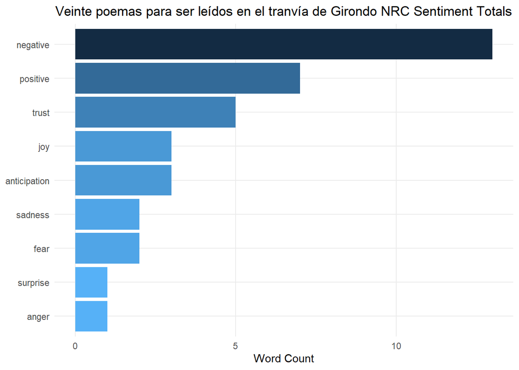

```r
theme_poem <- function(aticks = element_blank(),
                         pgminor = element_blank(),
                         lt = element_blank(),
                         lp = "none")
{
  theme(plot.title = element_text(hjust = 0.5), #Center the title
        axis.ticks = aticks, #Set axis ticks to on or off
        panel.grid.minor = pgminor, #Turn the minor grid lines on or off
        legend.title = lt, #Turn the legend title on or off
        legend.position = lp) #Turn the legend on or off
}

girondosentiment %>%
  group_by(sentiment) %>%
  summarise(word_count = n()) %>%
  ungroup() %>%
  mutate(sentiment = reorder(sentiment, word_count)) %>%
  ggplot(aes(sentiment, word_count, fill = -word_count)) +
  geom_col() +
  guides(fill = FALSE) +
  theme_minimal() + theme_poem() +
  labs(x = NULL, y = "Word Count") +
  ggtitle("Veinte poemas para ser leídos en el tranvía de Girondo NRC Sentiment Totals") +
  coord_flip()
```

La mayoría de las palabras parecen tener un valor negativo. Veamos con qué sentimiento coinciden las palabras de modo individualizado.

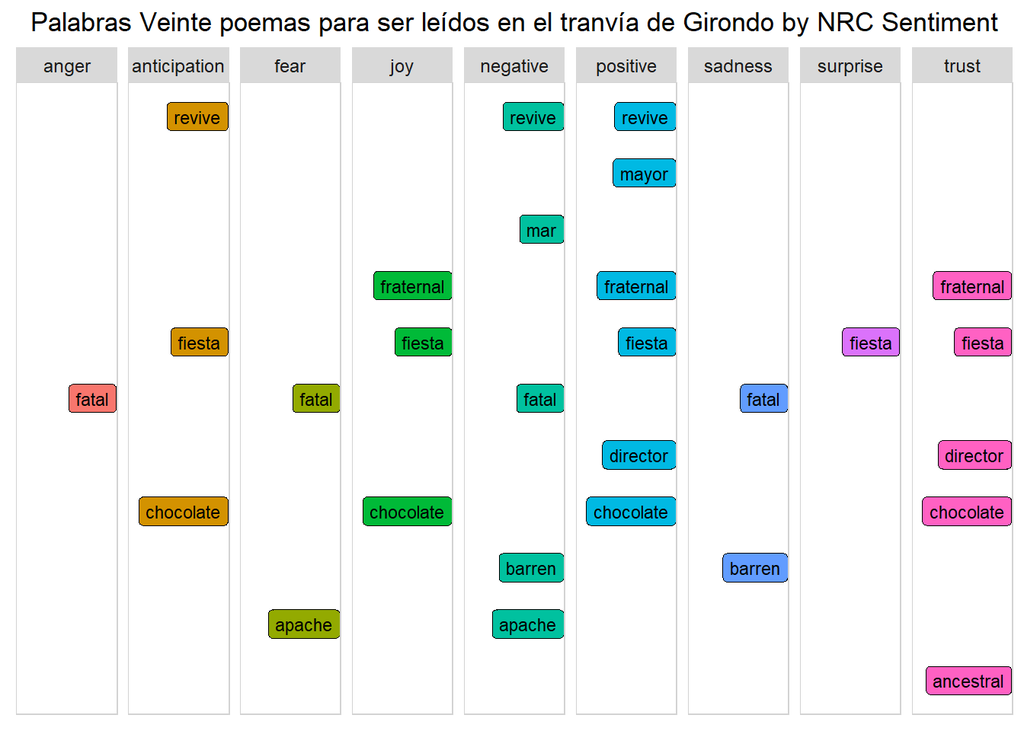

```r
library(ggrepel)

plot_words <- girondosentiment %>%
  group_by(sentiment) %>%
  count(word, sort = TRUE) %>%
  arrange(desc(n)) %>%
  ungroup()

plot_words %>%
  ggplot(aes(word, 1, label = word, fill = sentiment)) +
  geom_point(color = "white") +
  geom_label_repel(force = 1, nudge_y = 0.5,
                   direction = "y",
                   box.padding = 0.04,
                   segment.color = "white",
                   size = 3) +
  facet_grid(~sentiment) +
  theme_poem() +
  theme(axis.text.y = element_blank(), axis.line.x = element_blank(),
        axis.title.x = element_blank(), axis.text.x = element_blank(),
        axis.ticks.x = element_blank(),
        panel.grid = element_blank(), panel.background = element_blank(),
        panel.border = element_rect("lightgray", fill = NA),
        strip.text.x = element_text(size = 9)) +
  xlab(NULL) + ylab(NULL) +
  ggtitle("Palabras Veinte poemas para ser leídos en el tranvía de Girondo by NRC Sentiment") +
  coord_flip()
```

A la vista de los resultados, parece que puede haber palabras que están siendo clasificas erróneamente, por ejemplo, *mar* la clasifica con valor negativo. Centrémonos en una clasificación de valor positivo o negativo unicamente.

```r
girondosentiment_index <- tidy_girondo %>%
  inner_join(get_sentiments("nrc")%>%
               filter(sentiment %in% c("positive",
                                       "negative"))) %>%
  count(index = line, sentiment) %>%
  spread(sentiment, n, fill = 0) %>%
  mutate(sentiment = positive - negative)
```

Vamos a generar un marco de datos que agrega el sentimiento por línea. Veamos la trayectoria que sigue a lo largo del texto, positivo son las barras azules y negativo las rojas.

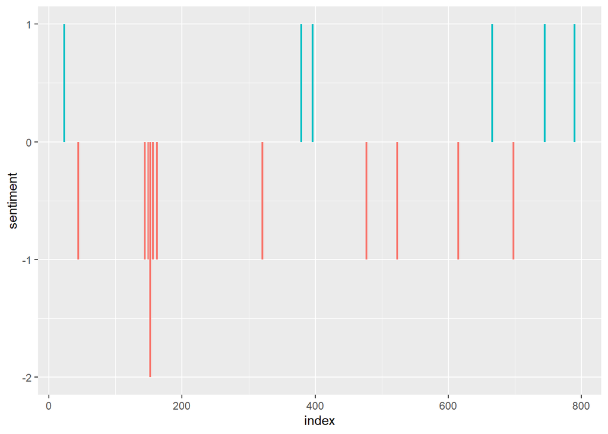

```r
girondosentiment_index %>%
  ggplot(aes(index, sentiment, fill = sentiment > 0)) +
  geom_col(show.legend = FALSE)
```

Como se muestra en el gráfico expuesto, el texto (poemario) comienza de manera algo neutral (positivo y negativo), con una caída poco después inclinándose a valores negativos. Más de la mitad del poemario es negativo; pero al final toma calidez y positividad.

### Referencias, Links y Comentarios

**Referencias**

Parte de este código ha sido recopilado gracias a las lecciones del profesor [Santiago Mota](https://www.linkedin.com/in/santiagomota/), Master in Big Data and & Data Science at Complutense University of Madrid.

**Links**

- Interesante artículo que hace uso de la librería **library(janeaustenr)**, [If I Loved Natural Language Processing Less, I Might Be Able to Talk About It More](https://juliasilge.com/blog/if-i-loved-nlp-less/) por Julia Silge.
  - [Package ‘janeaustenr’ en Cran.](https://cran.r-project.org/web/packages/janeaustenr/janeaustenr.pdf)

  *[Statistics Sunday: Welcome to Sentiment Analysis with “Hotel California”.](https://www.r-bloggers.com/statistics-sunday-welcome-to-sentiment-analysis-with-hotel-california/)

**Comentarios**

El presente código ha sido ejecutado en el sistema operativo version Windows 10, 64 bits, escogiendo formato de codificación en RStudio UTF-8.

A work by [María Luisa Duque](https://www.linkedin.com/in/marialuisaduque/)

*marialdu@umc.es*